# Study 2 — Wave4+ Clean Pipeline (Attention + Hardcoded Longstring)

# 0) Config

- **Edit the `path`** below to your CSV export.
- Column names are **hard-coded** to your Wave4+ survey. If your export uses different labels, adjust in the **Column Map** section.
- This file creates:
  - `FirstItem` … `SeventhItem` (1–4: position of selected choice)
  - `longstring_run` via `{careless}` across those seven items
  - `exclude_reason` with `"attention_fail"` and `"longstring_outlier"`
  - `dat_final` after all exclusions

```r
# ---- PATH ----
path <- r"(C:\Users\terwo\Dropbox\USD\Dissertation\Collab folder\Data\Dissertation+-+Study+2+-+Wave4+_October+6,+2025_15.23.csv)"
```

# 1) Packages

```r
if (!requireNamespace("pacman", quietly = TRUE)) install.packages("pacman")
library(pacman)
pacman::p_load(readr, dplyr, stringr, ggplot2, broom, effectsize, careless)
```

# 2) Load

```r
raw0 <- readr::read_csv(
  path,
  col_types = cols(.default = col_character()),
  show_col_types = FALSE
)

# Drop the first two header-ish rows (labels + ImportId JSON)
stopifnot(nrow(raw0) >= 3)
dat <- raw0[-c(1,2), , drop = FALSE]

# Keep finished only (exact header "Finished")
dat <- dat %>% filter(Finished %in% c("True","true","1"))

# Coerce duration and score
dat[["Duration (in seconds)"]] <- suppressWarnings(as.numeric(dat[["Duration (in seconds)"]]))
dat[["SC0"]]                   <- suppressWarnings(as.numeric(dat[["SC0"]]))
dat$score <- dat[["SC0"]]

stopifnot(nrow(dat) > 0)
stopifnot(!all(is.na(dat$score)))
```

# 3) Derive factors (Version → hierarchy & chartjunk)

```r
stopifnot("Version" %in% names(dat))
dat$Version <- stringr::str_squish(dat$Version)

chart <- stringr::str_match(dat$Version, "(High|Medium|Low)Chartjunk$")[,2]
hier  <- stringr::str_remove(dat$Version, "(High|Medium|Low)Chartjunk$")

dat$chartjunk <- factor(chart, levels = c("Low","Medium","High"), ordered = TRUE)
dat$hierarchy <- factor(
  dplyr::recode(hier,
    "NoHierarchy"         = "NoHierarchy",
    "FloorplanHierarchy"  = "FloorplanHierarchy",
    "RoomHierarchy"       = "RoomHierarchy",
    "ImportanceHierarchy" = "ImportanceHierarchy",
    .default = NA_character_
  ),
  levels = c("NoHierarchy","FloorplanHierarchy","RoomHierarchy","ImportanceHierarchy")
)
```

# 4) Column Map (hard-coded)

These are the exact headers expected in your Wave4+ export. Adjust here if your CSV labels differ.

```r
# === Column Map (Wave4+ CSV using QIDs) ===
# AN display order (tokens like Q1|Q9|...|MetaInfo)
COL_AN      <- "Gistblock_DO"

# Seven items (Q1 & Q18 have per-row randomized choice order)
COL_Q1      <- "Q1"
COL_Q1_DO   <- "Q1_DO"

COL_Q9      <- "Q9"
COL_Q10     <- "Q10"
COL_Q14     <- "Q14"
COL_Q17     <- "Q17"

COL_Q18     <- "Q18"
COL_Q18_DO  <- "Q18_DO"

# Attention item (also one of the seven)
COL_Q20     <- "Q20"

# Fixed (non-DO) choice orders for 4-option questions
# (coerce source columns to character so match() works even if CSV parsed numerics)
dat[[COL_Q10]] <- as.character(dat[[COL_Q10]])
dat[[COL_Q14]] <- as.character(dat[[COL_Q14]])
dat[[COL_Q17]] <- as.character(dat[[COL_Q17]])
dat[[COL_Q9 ]] <- trimws(as.character(dat[[COL_Q9 ]]))
dat[[COL_Q20]] <- trimws(as.character(dat[[COL_Q20]]))

CHO_Q9  <- c("North","South","East","West")
CHO_Q10 <- c("0","1","2","3")
CHO_Q14 <- c("1","2","3","4")
CHO_Q17 <- c("0","1","2","3")
CHO_Q20 <- c("Smart home","IT infrastructure","Hospital bed display","Stock ticker")

req_cols <- c(COL_AN,COL_Q1,COL_Q1_DO,COL_Q9,COL_Q10,COL_Q14,COL_Q17,COL_Q18,COL_Q18_DO,COL_Q20)
if (!all(req_cols %in% names(dat))) {
  stop("Missing columns: ", paste(setdiff(req_cols, names(dat)), collapse = ", "))
}
```

# 5) Attention filter (Q20 must contain “smart home”)

```r
keep_idx <- grepl("smart[[:space:]]*home", dat[[COL_Q20]], ignore.case = TRUE)
keep_idx[is.na(keep_idx)] <- FALSE

dat$exclude_reason <- ifelse(keep_idx, NA_character_, "attention_fail")
dat_attn <- dat[keep_idx, , drop = FALSE]

message(sprintf("Attention filter kept %d / %d rows.", sum(keep_idx, na.rm = TRUE), nrow(dat)))
```

```
## Attention filter kept 883 / 1063 rows.
```

# 6) Build FirstItem…SeventhItem (1–4 positions)

Rules: - Parse `COL_AN` (pipe-separated tokens) → drop `MetaInfo` → take the first seven tokens as the **seen order**. - Map each token to one of `{Q1, Q9, Q10, Q14, Q17, Q18, Q20}`. - For Q1 & Q18, compute the selected **position** from the per-row “- Display Order” columns. - For fixed-order items, compute the position via `match(selected, CHO_*)`.

```r
# 6a) Parse AN into seven tokens per row
ORD_LIST <- strsplit(dat_attn[[COL_AN]], "\\|", perl = TRUE)
ORD_LIST <- lapply(ORD_LIST, function(v) {
  v <- v[!grepl("^\\s*MetaInfo\\s*$", v, ignore.case = TRUE)]
  if (length(v) >= 7) v[1:7] else c(v, rep(NA_character_, 7 - length(v)))
})

# 6b) Selected positions per item (1..4)

# Q1 and Q18: position derived from their row-specific Display Order
POS_Q1 <- as.integer(mapply(function(ans, do) {
  if (is.na(ans) || is.na(do)) return(NA_integer_)
  ch <- strsplit(do, "\\|", perl = TRUE)[[1]]
  match(ans, ch)
}, dat_attn[[COL_Q1]], dat_attn[[COL_Q1_DO]]))

POS_Q18 <- as.integer(mapply(function(ans, do) {
  if (is.na(ans) || is.na(do)) return(NA_integer_)
  ch <- strsplit(do, "\\|", perl = TRUE)[[1]]
  match(ans, ch)
}, dat_attn[[COL_Q18]], dat_attn[[COL_Q18_DO]]))

# Fixed-order items
POS_Q9  <- as.integer(match(dat_attn[[COL_Q9]],  CHO_Q9))
POS_Q10 <- as.integer(match(dat_attn[[COL_Q10]], CHO_Q10))
POS_Q14 <- as.integer(match(dat_attn[[COL_Q14]], CHO_Q14))
POS_Q17 <- as.integer(match(dat_attn[[COL_Q17]], CHO_Q17))
POS_Q20 <- as.integer(match(dat_attn[[COL_Q20]], CHO_Q20))

# Mapping token → vector of positions in fixed order c(Q1,Q9,Q10,Q14,Q17,Q18,Q20)
QKEYS <- c("Q1","Q9","Q10","Q14","Q17","Q18","Q20")

# Helper inline (no separate functions): index into the packed vector by token
pick_by_token <- function(tok, p1,p9,p10,p14,p17,p18,p20) {
  idx <- match(tok, QKEYS)
  c(p1,p9,p10,p14,p17,p18,p20)[idx]
}

FirstItem   <- as.integer(mapply(function(ord, p1,p9,p10,p14,p17,p18,p20) pick_by_token(ord[1], p1,p9,p10,p14,p17,p18,p20),
                                ORD_LIST, POS_Q1, POS_Q9, POS_Q10, POS_Q14, POS_Q17, POS_Q18, POS_Q20))
SecondItem  <- as.integer(mapply(function(ord, p1,p9,p10,p14,p17,p18,p20) pick_by_token(ord[2], p1,p9,p10,p14,p17,p18,p20),
                                ORD_LIST, POS_Q1, POS_Q9, POS_Q10, POS_Q14, POS_Q17, POS_Q18, POS_Q20))
ThirdItem   <- as.integer(mapply(function(ord, p1,p9,p10,p14,p17,p18,p20) pick_by_token(ord[3], p1,p9,p10,p14,p17,p18,p20),
                                ORD_LIST, POS_Q1, POS_Q9, POS_Q10, POS_Q14, POS_Q17, POS_Q18, POS_Q20))
FourthItem  <- as.integer(mapply(function(ord, p1,p9,p10,p14,p17,p18,p20) pick_by_token(ord[4], p1,p9,p10,p14,p17,p18,p20),
                                ORD_LIST, POS_Q1, POS_Q9, POS_Q10, POS_Q14, POS_Q17, POS_Q18, POS_Q20))
FifthItem   <- as.integer(mapply(function(ord, p1,p9,p10,p14,p17,p18,p20) pick_by_token(ord[5], p1,p9,p10,p14,p17,p18,p20),
                                ORD_LIST, POS_Q1, POS_Q9, POS_Q10, POS_Q14, POS_Q17, POS_Q18, POS_Q20))
SixthItem   <- as.integer(mapply(function(ord, p1,p9,p10,p14,p17,p18,p20) pick_by_token(ord[6], p1,p9,p10,p14,p17,p18,p20),
                                ORD_LIST, POS_Q1, POS_Q9, POS_Q10, POS_Q14, POS_Q17, POS_Q18, POS_Q20))
SeventhItem <- as.integer(mapply(function(ord, p1,p9,p10,p14,p17,p18,p20) pick_by_token(ord[7], p1,p9,p10,p14,p17,p18,p20),
                                ORD_LIST, POS_Q1, POS_Q9, POS_Q10, POS_Q14, POS_Q17, POS_Q18, POS_Q20))

dat_attn$FirstItem   <- FirstItem
dat_attn$SecondItem  <- SecondItem
dat_attn$ThirdItem   <- ThirdItem
dat_attn$FourthItem  <- FourthItem
dat_attn$FifthItem   <- FifthItem
dat_attn$SixthItem   <- SixthItem
dat_attn$SeventhItem <- SeventhItem
```

# 7) Longstring via `{careless}`

We compute longest run across the seven 1–4 codes. To avoid NA runs, we replace missing entries with **unique per-column sentinels** so consecutive NAs never match.

```r
ls_mat <- dat_attn[, c("FirstItem","SecondItem","ThirdItem","FourthItem","FifthItem","SixthItem","SeventhItem")]

# Clean blanks → NA_integer_
for (j in seq_along(ls_mat)) {
  x <- ls_mat[[j]]
  x[x %in% c("", "NA")] <- NA
  ls_mat[[j]] <- suppressWarnings(as.integer(x))
}

# Replace NA with unique per-column codes (breaks NA runs)
for (j in seq_along(ls_mat)) {
  idx <- is.na(ls_mat[[j]])
  if (any(idx)) ls_mat[[j]][idx] <- -j
}

dat_attn$longstring_run <- as.integer(careless::longstring(ls_mat))

# Tukey fence to flag outliers; set fixed cutoff if preferred
q3  <- stats::quantile(dat_attn$longstring_run, 0.75, na.rm = TRUE)
iqr <- stats::IQR(dat_attn$longstring_run, na.rm = TRUE)
thr <- q3 + 1.5 * iqr
flag <- !is.na(dat_attn$longstring_run) & dat_attn$longstring_run > thr

dat_attn$exclude_reason <- ifelse(
  is.na(dat_attn$exclude_reason) & flag, "longstring_outlier",
  ifelse(!is.na(dat_attn$exclude_reason) & flag,
         paste(dat_attn$exclude_reason, "+ longstring_outlier"),
         dat_attn$exclude_reason)
)

dat_final <- dat_attn[!flag, , drop = FALSE]

cat("Longstring on First..Seventh: threshold >", round(thr, 2),
    "| removed", sum(flag, na.rm = TRUE), "rows.\n")
```

```
## Longstring on First..Seventh: threshold > 4.5 | removed 34 rows.
```

# 8) Quick EDA (optional)

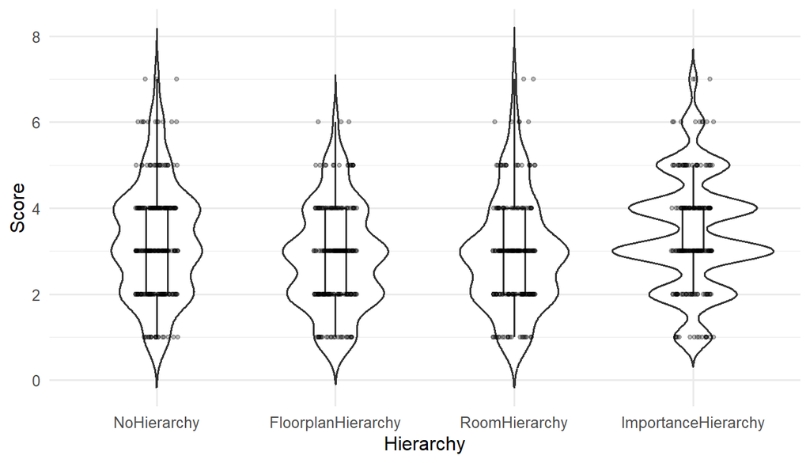

```r
# Score ~ hierarchy
ggplot(dat_final, aes(hierarchy, score)) +
  geom_violin(trim = FALSE) +
  geom_boxplot(width = .12, outlier.shape = NA) +
  geom_jitter(width = .12, height = 0, alpha = .25, size = 1) +
  labs(y = "Score", x = "Hierarchy") +
  theme_minimal(base_size = 12)
```

[figure not shown]

```r
# Score ~ chartjunk
ggplot(dat_final, aes(chartjunk, score)) +
  geom_violin(trim = FALSE) +
  geom_boxplot(width = .12, outlier.shape = NA) +
  geom_jitter(width = .12, height = 0, alpha = .25, size = 1) +
  labs(x = "Chartjunk", y = "Score") +
  ylim (c(1,7))+
  theme_minimal(base_size = 12)
```

# 9) Sanity tables

```r
table(dat_attn$exclude_reason, useNA = "ifany")
```

```
##
## longstring_outlier               <NA>
##                 34                849
```

```r
summary(dat_attn$longstring_run)
```

```
##    Min. 1st Qu.  Median    Mean 3rd Qu.    Max.
##   1.000   2.000   2.000   2.345   3.000   7.000
```

```r
# Peek at the First..Seventh encodings
head(dat_attn[, c("FirstItem","SecondItem","ThirdItem","FourthItem","FifthItem","SixthItem","SeventhItem")], 10)
```

| FirstItem | SecondItem | ThirdItem | FourthItem | FifthItem | SixthItem | SeventhItem |
| --- | --- | --- | --- | --- | --- | --- |
| 3 | 2 | 3 | 1 | 1 | 2 | 2 |
| 3 | 4 | 1 | 2 | 1 | 1 | 4 |
| 1 | 4 | 1 | 4 | 1 | 2 | 4 |
| 1 | 4 | 1 | 3 | 3 | 3 | 2 |
| 2 | 2 | 3 | 3 | 4 | 3 | 1 |
| 3 | 2 | 2 | 4 | 2 | 1 | 2 |
| 3 | 4 | 1 | 1 | 1 | 3 | 2 |
| 3 | 2 | 1 | 1 | 1 | 3 | 4 |
| 2 | 3 | 3 | 2 | 1 | 3 | 2 |
| 3 | 1 | 2 | 2 | 2 | 3 | 1 |

```r
# ---- ANCOVA: adjust for dashboard use (Never vs Otherwise) ----
suppressPackageStartupMessages({
  p_load(car)
  p_load(emmeans)
  p_load(effectsize)
  p_load(ggplot2)
})

# 1) Recode usage to binary factor (ref = Otherwise)
dat_final$use_never <- ifelse(tolower(trimws(dat_final$DataDashboardUsage)) == "never",
                              "Never", "Otherwise")
dat_final$use_never <- factor(dat_final$use_never, levels = c("Otherwise","Never"))

# (Optional) sanity check
table(dat_final$use_never, useNA = "ifany")
```

```
##
## Otherwise     Never
##       243       606
```

```r
# 2) Fit ANCOVA (binary covariate)
m_anc <- lm(score ~ hierarchy * chartjunk + use_never, data = dat_final)

# 3) Type-III tests with sum contrasts
old_contr <- options(contrasts = c("contr.sum","contr.poly"))
anc_tests <- car::Anova(m_anc, type = 3)
options(old_contr)

anc_tests
```

|  | Sum Sq | Df | F value | Pr(>F) |
| --- | --- | --- | --- | --- |
| (Intercept) | 1490.942096 | 1 | 920.3100352 | 6.599342e-137 |
| hierarchy | 41.526558 | 3 | 8.5443309 | 1.360432e-05 |
| chartjunk | 5.604456 | 2 | 1.7297243 | 1.779673e-01 |
| use_never | 1.056800 | 1 | 0.6523285 | 4.195112e-01 |
| hierarchy:chartjunk | 3.457699 | 6 | 0.3557209 | 9.067066e-01 |
| Residuals | 1354.356189 | 836 | NA | NA |

```r
# 4) Effect sizes (partial eta^2)
eta_squared(anc_tests, partial = TRUE)
```

```
## Type 3 ANOVAs only give sensible and informative results when covariates
##   are mean-centered and factors are coded with orthogonal contrasts (such
##   as those produced by `contr.sum`, `contr.poly`, or `contr.helmert`, but
##   *not* by the default `contr.treatment`).
```

| Parameter | Eta2_partial | CI | CI_low | CI_high |
| --- | --- | --- | --- | --- |
| hierarchy | 0.0297493165 | 0.95 | 0.01175132 | 1 |
| chartjunk | 0.0041210430 | 0.95 | 0.00000000 | 1 |
| use_never | 0.0007796888 | 0.95 | 0.00000000 | 1 |
| hierarchy:chartjunk | 0.0025465194 | 0.95 | 0.00000000 | 1 |

```r
# 5) Adjusted means (EMMs) for hierarchy x chartjunk
#    weights = "proportional" averages over use_never by its sample proportions.
#    If you prefer equal weighting across use_never levels, set weights = "equal".
emm_anc <- emmeans(m_anc, ~ hierarchy * chartjunk, weights = "proportional")
confint(emm_anc)
```

|  | hierarchy | chartjunk | emmean | SE | df | lower.CL | upper.CL |
| --- | --- | --- | --- | --- | --- | --- | --- |
| 1 | NoHierarchy | Low | 3.413956 | 0.1617851 | 836 | 3.096403 | 3.731509 |
| 2 | FloorplanHierarchy | Low | 2.868060 | 0.1604762 | 836 | 2.553076 | 3.183044 |
| 3 | RoomHierarchy | Low | 3.059498 | 0.1500814 | 836 | 2.764917 | 3.354079 |
| 4 | ImportanceHierarchy | Low | 3.590797 | 0.1510575 | 836 | 3.294301 | 3.887294 |
| 5 | NoHierarchy | Medium | 3.380308 | 0.1592368 | 836 | 3.067757 | 3.692859 |
| 6 | FloorplanHierarchy | Medium | 2.936782 | 0.1491141 | 836 | 2.644099 | 3.229464 |
| 7 | RoomHierarchy | Medium | 2.906101 | 0.1630601 | 836 | 2.586046 | 3.226157 |
| 8 | ImportanceHierarchy | Medium | 3.423570 | 0.1502511 | 836 | 3.128657 | 3.718484 |
| 9 | NoHierarchy | High | 3.095121 | 0.1167256 | 836 | 2.866012 | 3.324231 |
| 10 | FloorplanHierarchy | High | 2.747650 | 0.1555078 | 836 | 2.442419 | 3.052882 |

[output cut: 2 more lines]

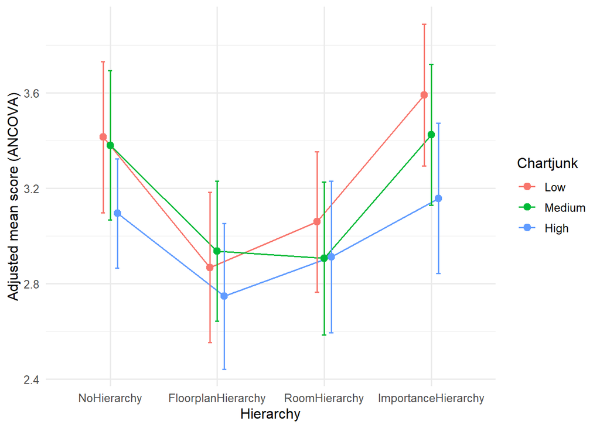

```r
# 6) Plot adjusted means with 95% CIs
emm_df <- as.data.frame(confint(emm_anc))
ggplot(emm_df, aes(hierarchy, emmean, group = chartjunk, color = chartjunk)) +
  geom_line(position = position_dodge(width = .2)) +
  geom_point(position = position_dodge(width = .2), size = 2.5) +
  geom_errorbar(aes(ymin = lower.CL, ymax = upper.CL),
                width = .12, position = position_dodge(width = .2)) +
  labs(x = "Hierarchy", y = "Adjusted mean score (ANCOVA)",
       color = "Chartjunk") +
  theme_minimal(base_size = 12)
```

```r
# 7) (Optional) follow-ups
# Pairwise simple effects of chartjunk within each hierarchy (Tukey-adjusted)
pairs(emmeans(m_anc, ~ chartjunk | hierarchy, weights = "proportional"),
      adjust = "tukey")
```

```
## hierarchy = NoHierarchy:
##  contrast      estimate    SE  df t.ratio p.value
##  Low - Medium   0.03365 0.227 836   0.148  0.9880
##  Low - High     0.31883 0.200 836   1.597  0.2473
##  Medium - High  0.28519 0.197 836   1.445  0.3182
##
## hierarchy = FloorplanHierarchy:
##  contrast      estimate    SE  df t.ratio p.value
##  Low - Medium  -0.06872 0.219 836  -0.313  0.9473
##  Low - High     0.12041 0.224 836   0.539  0.8522
##  Medium - High  0.18913 0.215 836   0.878  0.6543
##
## hierarchy = RoomHierarchy:
##  contrast      estimate    SE  df t.ratio p.value
##  Low - Medium   0.15340 0.221 836   0.693  0.7679
##  Low - High     0.14681 0.221 836   0.665  0.7841
##  Medium - High -0.00659 0.230 836  -0.029  0.9995
##
## hierarchy = ImportanceHierarchy:
##  contrast      estimate    SE  df t.ratio p.value
##  Low - Medium   0.16723 0.213 836   0.785  0.7123
##  Low - High     0.43328 0.220 836   1.967  0.1212
##  Medium - High  0.26605 0.220 836   1.211  0.4470
##
## Results are averaged over the levels of: use_never
## P value adjustment: tukey method for comparing a family of 3 estimates
```

```r
# Pairwise simple effects of hierarchy within each chartjunk
pairs(emmeans(m_anc, ~ hierarchy | chartjunk, weights = "proportional"),
      adjust = "tukey")
```

```
## chartjunk = Low:
##  contrast                                 estimate    SE  df t.ratio p.value
##  NoHierarchy - FloorplanHierarchy           0.5459 0.228 836   2.397  0.0783
##  NoHierarchy - RoomHierarchy                0.3545 0.221 836   1.605  0.3762
##  NoHierarchy - ImportanceHierarchy         -0.1768 0.221 836  -0.799  0.8549
##  FloorplanHierarchy - RoomHierarchy        -0.1914 0.220 836  -0.871  0.8200
##  FloorplanHierarchy - ImportanceHierarchy  -0.7227 0.220 836  -3.280  0.0059
##  RoomHierarchy - ImportanceHierarchy       -0.5313 0.213 836  -2.495  0.0614
##
## chartjunk = Medium:
##  contrast                                 estimate    SE  df t.ratio p.value
##  NoHierarchy - FloorplanHierarchy           0.4435 0.218 836   2.035  0.1760
##  NoHierarchy - RoomHierarchy                0.4742 0.228 836   2.082  0.1598
##  NoHierarchy - ImportanceHierarchy         -0.0433 0.219 836  -0.197  0.9973
##  FloorplanHierarchy - RoomHierarchy         0.0307 0.221 836   0.139  0.9990
##  FloorplanHierarchy - ImportanceHierarchy  -0.4868 0.212 836  -2.297  0.0996
##  RoomHierarchy - ImportanceHierarchy       -0.5175 0.222 836  -2.332  0.0918
##
## chartjunk = High:
##  contrast                                 estimate    SE  df t.ratio p.value
##  NoHierarchy - FloorplanHierarchy           0.3475 0.194 836   1.787  0.2801
##  NoHierarchy - RoomHierarchy                0.1824 0.200 836   0.914  0.7976
##  NoHierarchy - ImportanceHierarchy         -0.0624 0.198 836  -0.315  0.9892
##  FloorplanHierarchy - RoomHierarchy        -0.1650 0.225 836  -0.735  0.8830
##  FloorplanHierarchy - ImportanceHierarchy  -0.4099 0.223 836  -1.835  0.2577
##  RoomHierarchy - ImportanceHierarchy       -0.2448 0.228 836  -1.075  0.7050
##
## Results are averaged over the levels of: use_never
## P value adjustment: tukey method for comparing a family of 4 estimates
```

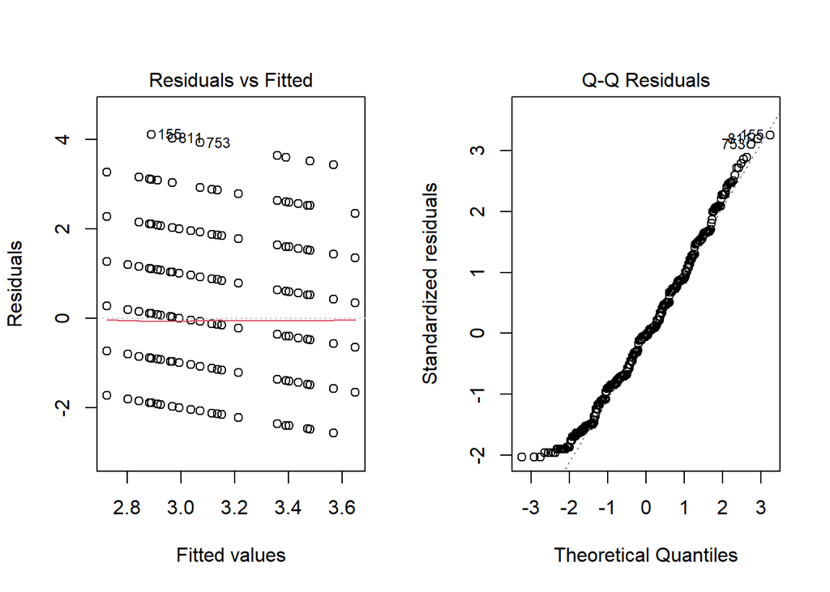

```r
# 8) (Optional) model diagnostics
par(mfrow = c(1,2))
plot(m_anc, which = 1)  # Residuals vs Fitted
plot(m_anc, which = 2)  # Normal Q-Q
```

```r
par(mfrow = c(1,1))
```

```
## Ignoring unknown labels:
## • linetype : "chartjunk"
## • shape : "chartjunk"
```

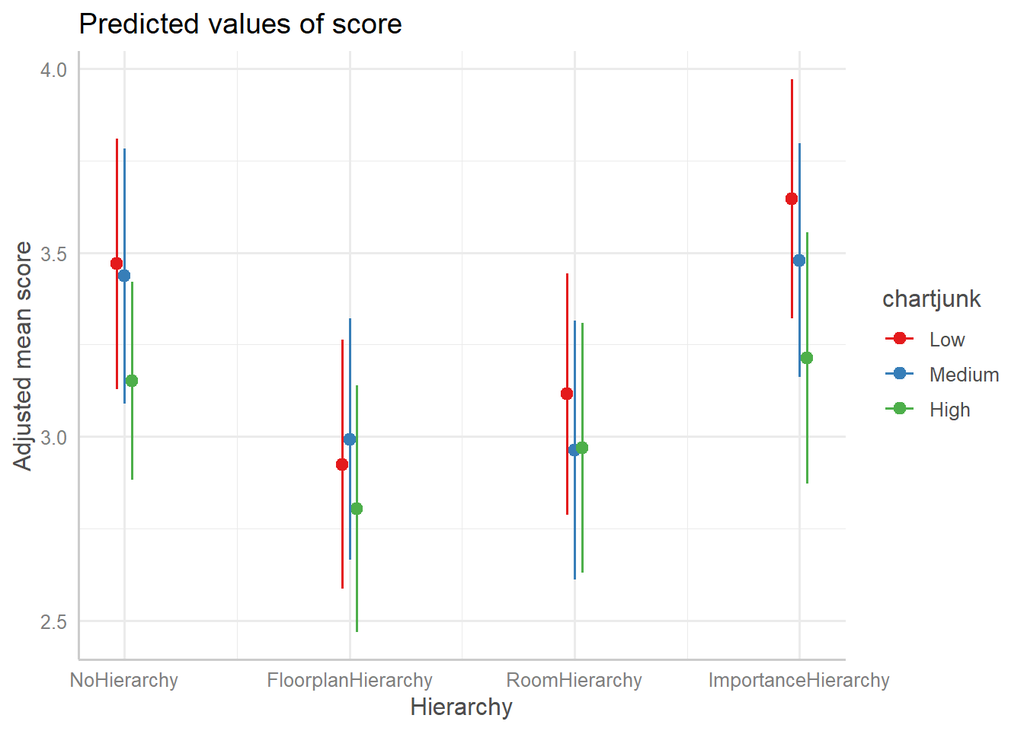

```r
# ---- sjPlot visuals (ANCOVA) ----
pacman::p_load(sjPlot, sjlabelled)

# Optional: consistent look + quiet color codes in console
theme_set(sjPlot::theme_sjplot())
options(cli.num_colors = 1, crayon.enabled = FALSE)

# 1) Interaction: hierarchy × chartjunk (averages over use_never by sample mix)
p_int <- sjPlot::plot_model(
  m_anc,
  type  = "int",
  terms = c("hierarchy", "chartjunk"),   # x, group
  ci.lvl = 0.95
) + labs(x = "Hierarchy", y = "Adjusted mean score") +
    guides(linetype = "none", shape = "none")
p_int
```

```
## Ignoring unknown labels:
## • linetype : "chartjunk"
## • shape : "chartjunk"
```

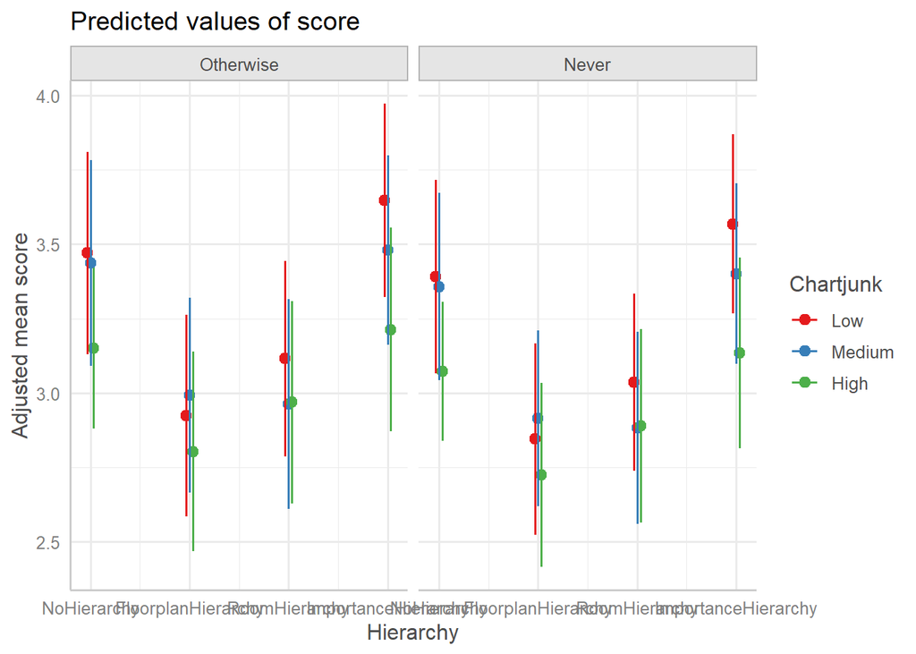

```r
# 2) Predicted means, explicitly showing both use_never levels
# terms = c(x, group, facet)
p_pred <- sjPlot::plot_model(
  m_anc,
  type  = "pred",
  terms = c("hierarchy", "chartjunk", "use_never")
) + labs(x = "Hierarchy", y = "Adjusted mean score", color = "Chartjunk") +
    guides(linetype = "none", shape = "none")
p_pred
```

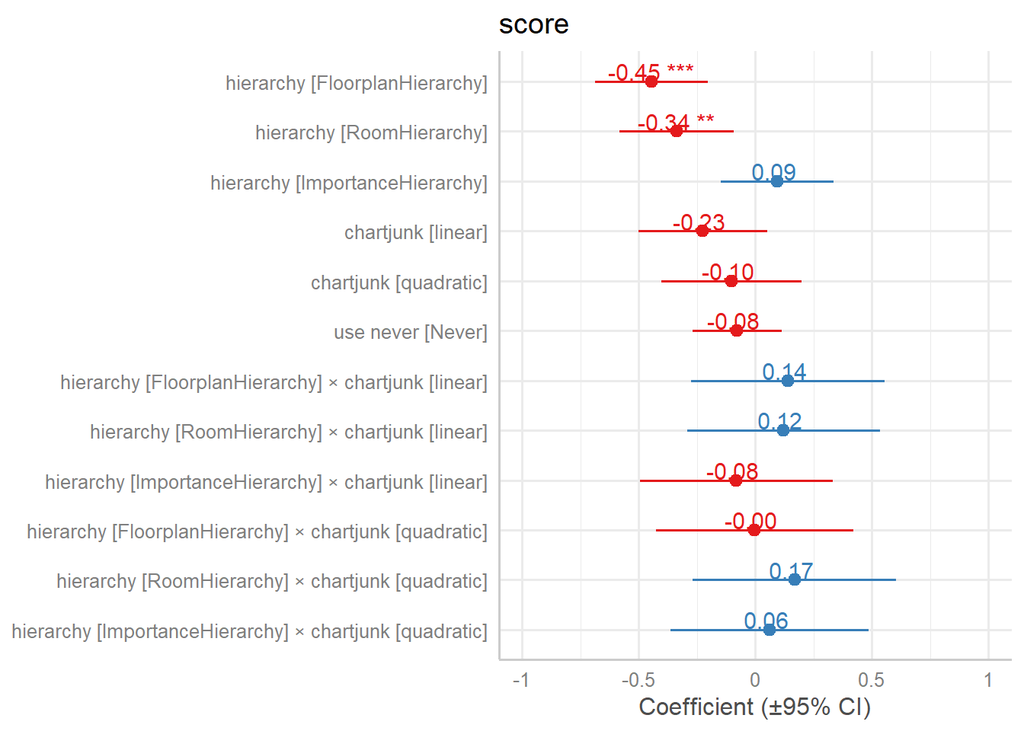

```r
# 3) Coefficient forest (fixed effects with 95% CI)
p_coef <- sjPlot::plot_model(
  m_anc,
  type = "est",          # estimated coefficients
  show.values = TRUE,
  value.offset = .2
) + labs(x = NULL, y = "Coefficient (±95% CI)")
p_coef
```

```r
# 4) Model table (nice HTML output in the notebook)
sjPlot::tab_model(
  m_anc,
  dv.labels = "Score (ANCOVA)",
  show.ci = TRUE,
  show.std = TRUE,
  p.style = "stars",
  string.pred = "Predictor",
  string.est  = "b"
)
```

Score (ANCOVA)

Predictor

b

std. Beta

CI

standardized CI

(Intercept)

3.35 ***

0.18

-Inf – Inf

-Inf – Inf

hierarchy  
[FloorplanHierarchy]

-0.45 ***

-0.35

-Inf – Inf

-Inf – Inf

hierarchy [RoomHierarchy]

-0.34 **

-0.26

-Inf – Inf

-Inf – Inf

hierarchy  
[ImportanceHierarchy]

0.09

0.07

-Inf – Inf

-Inf – Inf

chartjunk [linear]

-0.23

-0.17

-Inf – Inf

-Inf – Inf

chartjunk [quadratic]

-0.10

-0.08

-Inf – Inf

-Inf – Inf

use never [Never]

-0.08

-0.06

-Inf – Inf

-Inf – Inf

hierarchy  
[FloorplanHierarchy] ×  
chartjunk [linear]

0.14

0.11

-Inf – Inf

-Inf – Inf

hierarchy [RoomHierarchy]  
× chartjunk [linear]

0.12

0.09

-Inf – Inf

-Inf – Inf

hierarchy  
[ImportanceHierarchy] ×  
chartjunk [linear]

-0.08

-0.06

-Inf – Inf

-Inf – Inf

hierarchy  
[FloorplanHierarchy] ×  
chartjunk [quadratic]

-0.00

-0.00

-Inf – Inf

-Inf – Inf

hierarchy [RoomHierarchy]  
× chartjunk [quadratic]

0.17

0.13

-Inf – Inf

-Inf – Inf

hierarchy  
[ImportanceHierarchy] ×  
chartjunk [quadratic]

0.06

0.05

-Inf – Inf

-Inf – Inf

Observations

849

R<sup>2</sup> / R<sup>2</sup> adjusted

0.039 / 0.025

- p<0.05 ** p<0.01 *** p<0.001

```r
m_mod <- lm(score ~ hierarchy * chartjunk * use_never, data = dat_final)
car::Anova(m_mod, type = 3)
```

|  | Sum Sq | Df | F value | Pr(>F) |
| --- | --- | --- | --- | --- |
| (Intercept) | 6.517740e+02 | 1 | 4.003925e+02 | 6.443571e-73 |
| hierarchy | 1.598297e+01 | 3 | 3.272842e+00 | 2.065922e-02 |
| chartjunk | 5.549784e-01 | 2 | 1.704649e-01 | 8.433024e-01 |
| use_never | 8.992487e-04 | 1 | 5.524192e-04 | 9.812543e-01 |
| hierarchy:chartjunk | 4.976289e+00 | 6 | 5.094990e-01 | 8.014400e-01 |
| hierarchy:use_never | 1.071395e+00 | 3 | 2.193902e-01 | 8.829640e-01 |
| chartjunk:use_never | 5.460804e-01 | 2 | 1.677318e-01 | 8.456094e-01 |
| hierarchy:chartjunk:use_never | 5.658166e+00 | 6 | 5.793131e-01 | 7.470304e-01 |
| Residuals | 1.342966e+03 | 825 | NA | NA |

```r
m_aov <- lm(score ~ hierarchy * chartjunk, data = dat_final)
m_anc <- lm(score ~ hierarchy * chartjunk + use_never, data = dat_final)

anova(m_aov, m_anc)   # nested F-test
```

|  | Res.Df | RSS | Df | Sum of Sq | F | Pr(>F) |
| --- | --- | --- | --- | --- | --- | --- |
| 1 | 837 | 1355.413 | NA | NA | NA | NA |
| 2 | 836 | 1354.356 | 1 | 1.0568 | 0.6523285 | 0.4195112 |

```r
AIC(m_aov, m_anc); BIC(m_aov, m_anc)
```

|  | df | AIC |
| --- | --- | --- |
| m_aov | 13 | 2832.522 |
| m_anc | 14 | 2833.860 |

|  | df | BIC |
| --- | --- | --- |
| m_aov | 13 | 2894.195 |
| m_anc | 14 | 2900.276 |

```r
# --- Final 2×3 ANOVA (no covariate) ---
p_load(car); p_load(emmeans); p_load(effectsize); p_load(sjPlot)

m_aov <- lm(score ~ hierarchy * chartjunk, data = dat_final)

# Type III with sum contrasts (reporting-friendly)
oldc <- options(contrasts = c("contr.sum","contr.poly"))
aov_tests <- car::Anova(m_aov, type = 3)
options(oldc)

aov_tests
```

|  | Sum Sq | Df | F value | Pr(>F) |
| --- | --- | --- | --- | --- |
| (Intercept) | 2434.138364 | 1 | 1503.1387674 | 4.669506e-189 |
| hierarchy | 41.914882 | 3 | 8.6278147 | 1.209836e-05 |
| chartjunk | 5.732277 | 2 | 1.7699093 | 1.709854e-01 |
| hierarchy:chartjunk | 3.497737 | 6 | 0.3599894 | 9.041826e-01 |
| Residuals | 1355.412990 | 837 | NA | NA |

```r
effectsize::eta_squared(aov_tests, partial = TRUE)
```

```
## Type 3 ANOVAs only give sensible and informative results when covariates
##   are mean-centered and factors are coded with orthogonal contrasts (such
##   as those produced by `contr.sum`, `contr.poly`, or `contr.helmert`, but
##   *not* by the default `contr.treatment`).
```

| Parameter | Eta2_partial | CI | CI_low | CI_high |
| --- | --- | --- | --- | --- |
| hierarchy | 0.029996455 | 0.95 | 0.01193097 | 1 |
| chartjunk | 0.004211363 | 0.95 | 0.00000000 | 1 |
| hierarchy:chartjunk | 0.002573927 | 0.95 | 0.00000000 | 1 |

```r
# EMMs + pairwise (Tukey)
emm <- emmeans(m_aov, ~ hierarchy * chartjunk)
pairs(emmeans(m_aov, ~ chartjunk | hierarchy), adjust = "tukey")
```

```
## hierarchy = NoHierarchy:
##  contrast      estimate    SE  df t.ratio p.value
##  Low - Medium    0.0444 0.227 837   0.196  0.9791
##  Low - High      0.3269 0.199 837   1.640  0.2294
##  Medium - High   0.2826 0.197 837   1.432  0.3247
##
## hierarchy = FloorplanHierarchy:
##  contrast      estimate    SE  df t.ratio p.value
##  Low - Medium   -0.0585 0.219 837  -0.267  0.9614
##  Low - High      0.1267 0.223 837   0.568  0.8374
##  Medium - High   0.1852 0.215 837   0.860  0.6654
##
## hierarchy = RoomHierarchy:
##  contrast      estimate    SE  df t.ratio p.value
##  Low - Medium    0.1539 0.221 837   0.695  0.7664
##  Low - High      0.1362 0.220 837   0.618  0.8104
##  Medium - High  -0.0177 0.229 837  -0.077  0.9967
##
## hierarchy = ImportanceHierarchy:
##  contrast      estimate    SE  df t.ratio p.value
##  Low - Medium    0.1610 0.213 837   0.756  0.7298
##  Low - High      0.4328 0.220 837   1.965  0.1216
##  Medium - High   0.2718 0.220 837   1.238  0.4310
##
## P value adjustment: tukey method for comparing a family of 3 estimates
```

```r
pairs(emmeans(m_aov, ~ hierarchy | chartjunk), adjust = "tukey")
```

```
## chartjunk = Low:
##  contrast                                 estimate    SE  df t.ratio p.value
##  NoHierarchy - FloorplanHierarchy           0.5463 0.228 837   2.400  0.0779
##  NoHierarchy - RoomHierarchy                0.3638 0.220 837   1.650  0.3511
##  NoHierarchy - ImportanceHierarchy         -0.1722 0.221 837  -0.778  0.8642
##  FloorplanHierarchy - RoomHierarchy        -0.1825 0.220 837  -0.831  0.8395
##  FloorplanHierarchy - ImportanceHierarchy  -0.7185 0.220 837  -3.262  0.0063
##  RoomHierarchy - ImportanceHierarchy       -0.5360 0.213 837  -2.518  0.0578
##
## chartjunk = Medium:
##  contrast                                 estimate    SE  df t.ratio p.value
##  NoHierarchy - FloorplanHierarchy           0.4435 0.218 837   2.035  0.1759
##  NoHierarchy - RoomHierarchy                0.4734 0.228 837   2.079  0.1609
##  NoHierarchy - ImportanceHierarchy         -0.0556 0.219 837  -0.254  0.9942
##  FloorplanHierarchy - RoomHierarchy         0.0299 0.221 837   0.135  0.9991
##  FloorplanHierarchy - ImportanceHierarchy  -0.4990 0.211 837  -2.361  0.0855
##  RoomHierarchy - ImportanceHierarchy       -0.5289 0.221 837  -2.388  0.0801
##
## chartjunk = High:
##  contrast                                 estimate    SE  df t.ratio p.value
##  NoHierarchy - FloorplanHierarchy           0.3462 0.194 837   1.781  0.2832
##  NoHierarchy - RoomHierarchy                0.1731 0.199 837   0.868  0.8212
##  NoHierarchy - ImportanceHierarchy         -0.0663 0.198 837  -0.334  0.9871
##  FloorplanHierarchy - RoomHierarchy        -0.1731 0.224 837  -0.772  0.8672
##  FloorplanHierarchy - ImportanceHierarchy  -0.4125 0.223 837  -1.847  0.2522
##  RoomHierarchy - ImportanceHierarchy       -0.2394 0.228 837  -1.052  0.7191
##
## P value adjustment: tukey method for comparing a family of 4 estimates
```

```
## Ignoring unknown labels:
## • linetype : "chartjunk"
## • shape : "chartjunk"
```

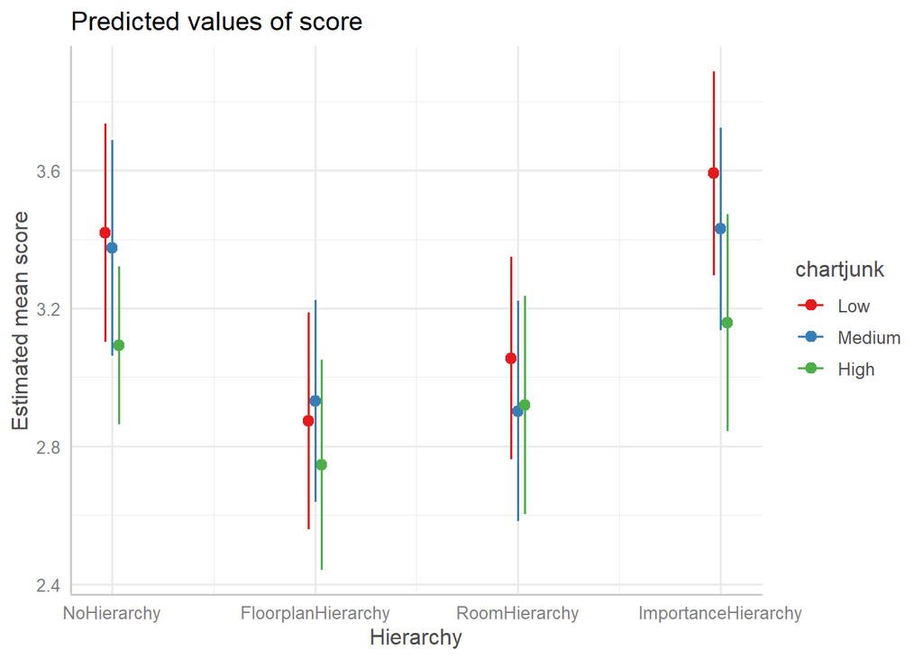

```r
# Plot (report-friendly)
theme_set(sjPlot::theme_sjplot())
sjPlot::plot_model(m_aov, type = "int",
                   terms = c("hierarchy","chartjunk"), ci.lvl = 0.95) +
  labs(x = "Hierarchy", y = "Estimated mean score") +
  guides(linetype = "none", shape = "none")
```

```r
# (Optional) basic assumptions
car::leveneTest(score ~ interaction(hierarchy, chartjunk), data = dat_final)
```

|  | Df | F value | Pr(>F) |
| --- | --- | --- | --- |
| group | 11 | 1.706248 | 0.06745929 |
|  | 837 | NA | NA |

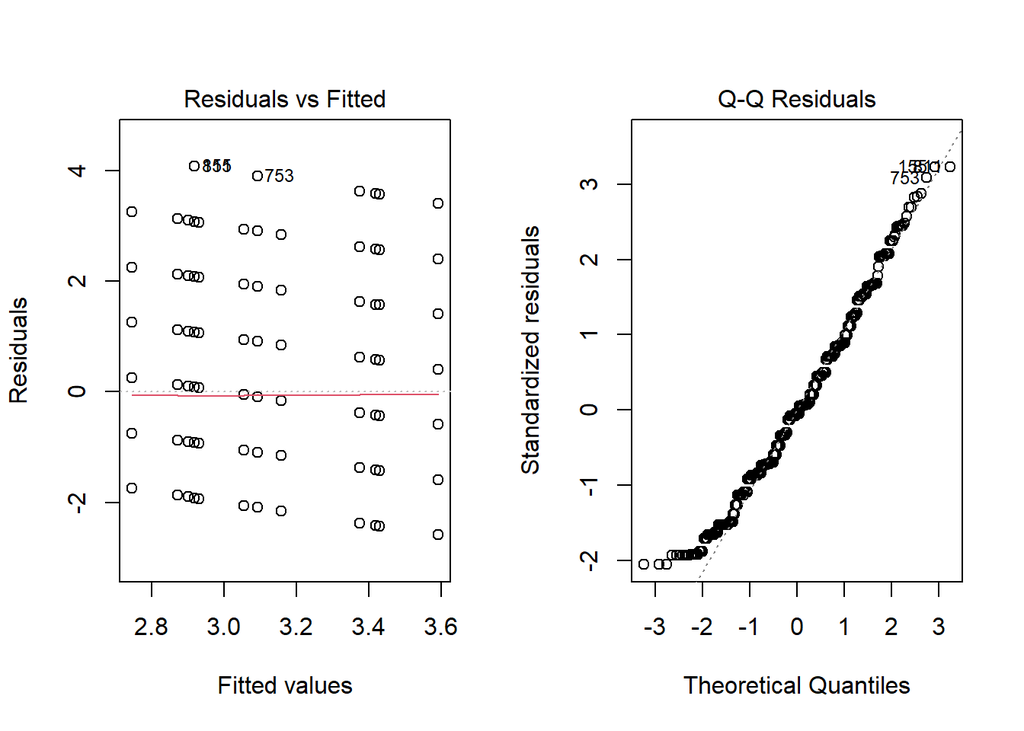

```r
par(mfrow = c(1,2)); plot(m_aov, which = 1); plot(m_aov, which = 2); par(mfrow = c(1,1))
```

```r
# 1) Omnibus 2×3 ANOVA + effect sizes
options(contrasts = c("contr.sum","contr.poly"))
m_aov <- lm(score ~ hierarchy * chartjunk, data = dat_final)
aov_tab <- car::Anova(m_aov, type = 3); aov_tab
```

|  | Sum Sq | Df | F value | Pr(>F) |
| --- | --- | --- | --- | --- |
| (Intercept) | 8037.590944 | 1 | 4963.4050077 | 0.000000e+00 |
| hierarchy | 41.914882 | 3 | 8.6278147 | 1.209836e-05 |
| chartjunk | 9.675091 | 2 | 2.9873004 | 5.096129e-02 |
| hierarchy:chartjunk | 3.497737 | 6 | 0.3599894 | 9.041826e-01 |
| Residuals | 1355.412990 | 837 | NA | NA |

```r
effectsize::eta_squared(aov_tab, partial = TRUE)
```

```
## Type 3 ANOVAs only give sensible and informative results when covariates
##   are mean-centered and factors are coded with orthogonal contrasts (such
##   as those produced by `contr.sum`, `contr.poly`, or `contr.helmert`, but
##   *not* by the default `contr.treatment`).
```

| Parameter | Eta2_partial | CI | CI_low | CI_high |
| --- | --- | --- | --- | --- |
| hierarchy | 0.029996455 | 0.95 | 0.01193097 | 1 |
| chartjunk | 0.007087522 | 0.95 | 0.00000000 | 1 |
| hierarchy:chartjunk | 0.002573927 | 0.95 | 0.00000000 | 1 |

```r
# 2) Planned linear trend for chartjunk (it’s ordered)
# overall (balanced over hierarchy) and within each hierarchy
p_load(emmeans)
emm_cj   <- emmeans(m_aov, ~ chartjunk, weights = "equal")
```

```
## NOTE: Results may be misleading due to involvement in interactions
```

```r
contrast(emm_cj, "poly")              # look at the Linear row
```

```
##  contrast  estimate    SE  df t.ratio p.value
##  linear      -0.256 0.108 837  -2.367  0.0182
##  quadratic   -0.105 0.189 837  -0.556  0.5781
##
## Results are averaged over the levels of: hierarchy
```

```r
emm_cj_h <- emmeans(m_aov, ~ chartjunk | hierarchy, weights = "equal")
contrast(emm_cj_h, "poly")            # Linear per-hierarchy
```

```
## hierarchy = NoHierarchy:
##  contrast  estimate    SE  df t.ratio p.value
##  linear      -0.327 0.199 837  -1.640  0.1013
##  quadratic   -0.238 0.375 837  -0.635  0.5259
##
## hierarchy = FloorplanHierarchy:
##  contrast  estimate    SE  df t.ratio p.value
##  linear      -0.127 0.223 837  -0.568  0.5705
##  quadratic   -0.244 0.372 837  -0.655  0.5129
##
## hierarchy = RoomHierarchy:
##  contrast  estimate    SE  df t.ratio p.value
##  linear      -0.136 0.220 837  -0.618  0.5369
##  quadratic    0.172 0.393 837   0.436  0.6628
##
## hierarchy = ImportanceHierarchy:
##  contrast  estimate    SE  df t.ratio p.value
##  linear      -0.433 0.220 837  -1.965  0.0497
##  quadratic   -0.111 0.372 837  -0.298  0.7659
```

```r
# 3) Simple effects of chartjunk within each hierarchy (Tukey)
pairs(emm_cj_h, adjust = "tukey")
```

```
## hierarchy = NoHierarchy:
##  contrast      estimate    SE  df t.ratio p.value
##  Low - Medium    0.0444 0.227 837   0.196  0.9791
##  Low - High      0.3269 0.199 837   1.640  0.2294
##  Medium - High   0.2826 0.197 837   1.432  0.3247
##
## hierarchy = FloorplanHierarchy:
##  contrast      estimate    SE  df t.ratio p.value
##  Low - Medium   -0.0585 0.219 837  -0.267  0.9614
##  Low - High      0.1267 0.223 837   0.568  0.8374
##  Medium - High   0.1852 0.215 837   0.860  0.6654
##
## hierarchy = RoomHierarchy:
##  contrast      estimate    SE  df t.ratio p.value
##  Low - Medium    0.1539 0.221 837   0.695  0.7664
##  Low - High      0.1362 0.220 837   0.618  0.8104
##  Medium - High  -0.0177 0.229 837  -0.077  0.9967
##
## hierarchy = ImportanceHierarchy:
##  contrast      estimate    SE  df t.ratio p.value
##  Low - Medium    0.1610 0.213 837   0.756  0.7298
##  Low - High      0.4328 0.220 837   1.965  0.1216
##  Medium - High   0.2718 0.220 837   1.238  0.4310
##
## P value adjustment: tukey method for comparing a family of 3 estimates
```

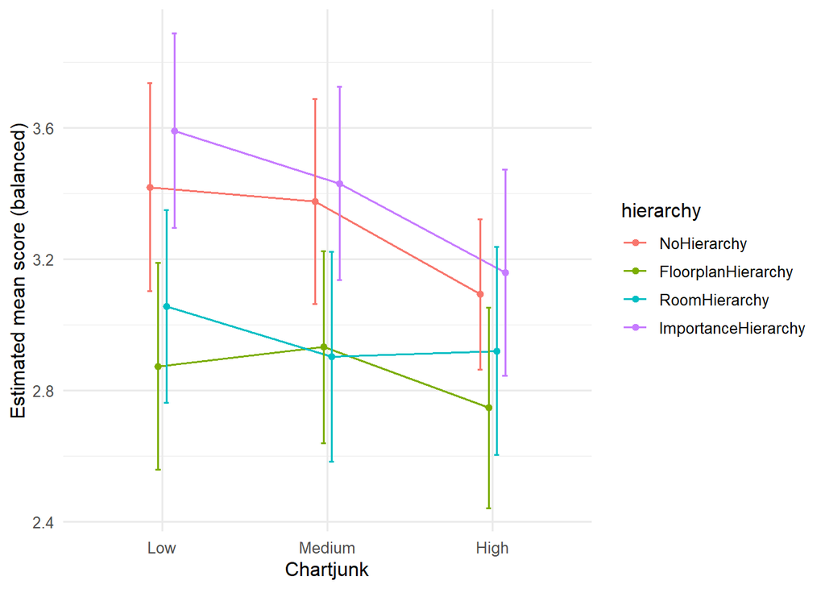

```r
# (Optional) visualize the monotone look you’re seeing
emm_df <- as.data.frame(confint(emm_cj_h))
ggplot(emm_df, aes(chartjunk, emmean, group = hierarchy, color = hierarchy)) +
  geom_line(position = position_dodge(.2)) +
  geom_point(position = position_dodge(.2)) +
  geom_errorbar(aes(ymin = lower.CL, ymax = upper.CL),
                width = .12, position = position_dodge(.2)) +
  labs(x = "Chartjunk", y = "Estimated mean score (balanced)") +
  theme_minimal(base_size = 12)
```

```r
# ensure ordered levels
dat_final$chartjunk <- factor(dat_final$chartjunk,
                               levels = c("Low","Medium","High"),
                               ordered = TRUE)

# contrasts: sum for hierarchy (Type III friendly), polynomial for chartjunk
contrasts(dat_final$hierarchy) <- contr.sum(4)
contrasts(dat_final$chartjunk)  <- contr.poly(3)

# refit the 2×3 model
m_aov <- lm(score ~ hierarchy * chartjunk, data = dat_final)

# overall Type III tests
car::Anova(m_aov, type = 3)
```

|  | Sum Sq | Df | F value | Pr(>F) |
| --- | --- | --- | --- | --- |
| (Intercept) | 8037.590944 | 1 | 4963.4050077 | 0.000000e+00 |
| hierarchy | 41.914882 | 3 | 8.6278147 | 1.209836e-05 |
| chartjunk | 9.675091 | 2 | 2.9873004 | 5.096129e-02 |
| hierarchy:chartjunk | 3.497737 | 6 | 0.3599894 | 9.041826e-01 |
| Residuals | 1355.412990 | 837 | NA | NA |

```r
p_load(emmeans)

# overall linear trend for chartjunk (balanced over hierarchy)
emm_cj <- emmeans(m_aov, ~ chartjunk, weights = "equal")
```

```
## NOTE: Results may be misleading due to involvement in interactions
```

```r
contrast(emm_cj, "poly")   # check the "Linear" row
```

```
##  contrast  estimate    SE  df t.ratio p.value
##  linear      -0.256 0.108 837  -2.367  0.0182
##  quadratic   -0.105 0.189 837  -0.556  0.5781
##
## Results are averaged over the levels of: hierarchy
```

```r
# linear trend within each hierarchy
emm_cj_h <- emmeans(m_aov, ~ chartjunk | hierarchy, weights = "equal")
contrast(emm_cj_h, "poly") # Linear per hierarchy level
```

```
## hierarchy = NoHierarchy:
##  contrast  estimate    SE  df t.ratio p.value
##  linear      -0.327 0.199 837  -1.640  0.1013
##  quadratic   -0.238 0.375 837  -0.635  0.5259
##
## hierarchy = FloorplanHierarchy:
##  contrast  estimate    SE  df t.ratio p.value
##  linear      -0.127 0.223 837  -0.568  0.5705
##  quadratic   -0.244 0.372 837  -0.655  0.5129
##
## hierarchy = RoomHierarchy:
##  contrast  estimate    SE  df t.ratio p.value
##  linear      -0.136 0.220 837  -0.618  0.5369
##  quadratic    0.172 0.393 837   0.436  0.6628
##
## hierarchy = ImportanceHierarchy:
##  contrast  estimate    SE  df t.ratio p.value
##  linear      -0.433 0.220 837  -1.965  0.0497
##  quadratic   -0.111 0.372 837  -0.298  0.7659
```

```r
# ---- linear contrast at a fixed hierarchy level -----------------------------
# deps
p_load(emmeans)
p_load(ggplot2)
p_load(sjPlot)  # for theme_sjplot()

plot_linear_contrast_at <- function(
  m,
  focal,                     # character: the factor you want the linear contrast on (e.g., "cond")
  moderator = "hierarchy",   # character: the factor to hold constant
  at_level = NULL,           # which level of moderator to hold fixed (e.g., "Manager")
  contrast = c("poly","custom"),  # "poly" for polynomial linear trend, or "custom"
  custom_weights = NULL,     # numeric vector if contrast = "custom" (length = #levels of focal)
  type = "response",         # EMM scale: "response" often nicer for GLMs
  emm_weights = "equal"      # how to average over other factors if present; "equal" is common
) {
  contrast <- match.arg(contrast)

  # discover default at_level if not provided
  mf <- tryCatch(model.frame(m), error = function(e) NULL)
  if (is.null(at_level)) {
    if (!is.null(mf) && moderator %in% names(mf) && is.factor(mf[[moderator]])) {
      at_level <- levels(mf[[moderator]])[1]
    } else {
      stop("Please provide 'at_level' (couldn't infer a factor level for ", moderator, ").")
    }
  }

  # build a reference grid with hierarchy held constant
  rg <- ref_grid(m, at = setNames(list(at_level), moderator), type = type)

  # EMMs for the focal factor at that hierarchy level
  emm <- emmeans(rg, as.formula(paste0("~ ", focal)), weights = emm_weights)

  # Linear contrast
  lin <- if (contrast == "poly") {
    # "poly" gives linear, quadratic, ...; take the linear component only
    contrast(emm, "poly")["linear"]
  } else {
    # custom weights you define in the order of levels(emm)
    if (is.null(custom_weights))
      stop("Provide 'custom_weights' when contrast = 'custom'.")
    if (length(custom_weights) != nrow(as.data.frame(emm)))
      stop("Length of 'custom_weights' must equal the number of levels in '", focal, "'.")
    contrast(emm, list(linear = custom_weights))
  }

  lin_sum <- summary(lin, infer = TRUE)
  tval <- lin_sum$t.ratio
  pval <- lin_sum$p.value

  # data frame for plotting
  emm_df <- as.data.frame(emm)
  emm_df$.xnum <- as.numeric(emm_df[[focal]])

  p <- ggplot(emm_df,
              aes(x = .xnum,
                  y = emmean,
                  ymin = lower.CL, ymax = upper.CL)) +
    geom_point(size = 3) +
    geom_line(group = 1) +
    geom_errorbar(width = 0.1) +
    geom_smooth(method = "lm", se = FALSE) +
    scale_x_continuous(breaks = emm_df$.xnum,
                       labels = emm_df[[focal]]) +
    labs(
      x = focal,
      y = paste("Estimated marginal mean (", type, " scale)", sep = ""),
      title = paste0("Linear contrast across ", focal,
                     " (", moderator, " = ", at_level, ")"),
      subtitle = paste0("t = ", round(tval, 2),
                        ", p = ", format.pval(pval, digits = 3, eps = 1e-4))
    ) +
    theme_sjplot()

  list(plot = p, emm = emm, linear_contrast = lin)
}
# -----------------------------------------------------------------------------

# EXAMPLE USAGE:
# pacman::p_load(lme4)
# m <- lmer(y ~ cond * hierarchy + (1|id), data = d)  # or lm()/glm()
# out <- plot_linear_contrast_at(m, focal = "cond", moderator = "hierarchy",
#                                at_level = "Manager", contrast = "poly",
#                                type = "response", emm_weights = "equal")
# out$plot
# # summary(out$linear_contrast)  # full stats table
```

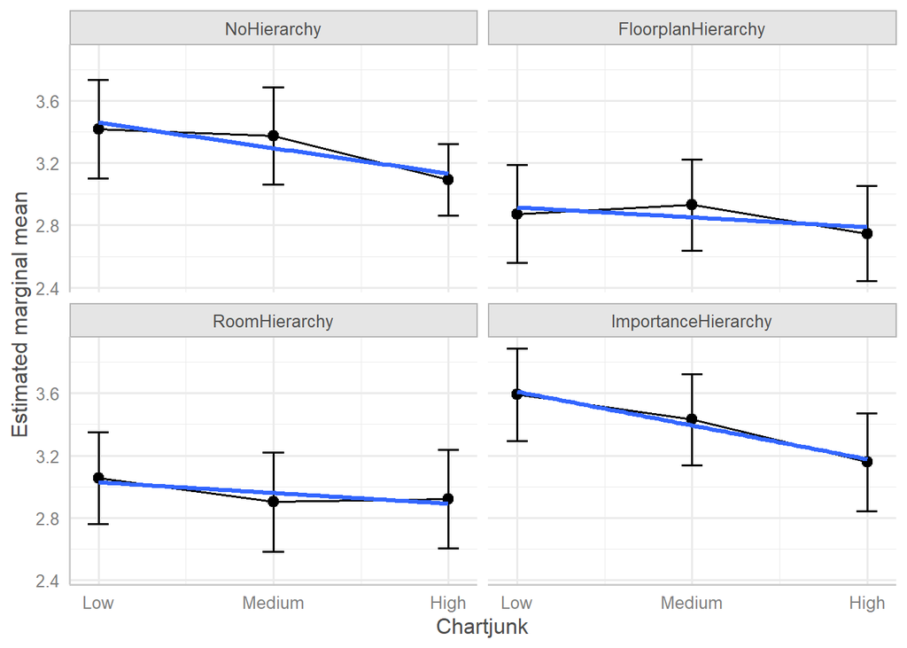

```r
# --- Linear contrasts for chartjunk while holding hierarchy constant ----

# pick which fitted model you want to use
# (no covariate 2×3)     or     (ANCOVA with use_never)
mod <- m_aov              # or: mod <- m_anc

# how emmeans averages over other factors not shown in the formula
# "equal" = simple average of cells; "proportional" = weighted by sample sizes
wts <- "equal"            # or: wts <- "proportional"

# Uses your existing m_aov (or m_anc), dat_final, and plot_linear_contrast_at()
emm_cj_h <- emmeans(mod, ~ chartjunk | hierarchy, weights = wts)
emm_df   <- as.data.frame(confint(emm_cj_h))
emm_df$xnum <- as.numeric(emm_df$chartjunk)

ggplot(emm_df, aes(x = xnum, y = emmean)) +
  facet_wrap(~ hierarchy) +
  geom_point(size = 2.5) +
  geom_line(group = 1) +
  geom_errorbar(aes(ymin = lower.CL, ymax = upper.CL), width = .12) +
  geom_smooth(method = "lm", se = FALSE) +
  scale_x_continuous(breaks = seq_along(levels(dat_final$chartjunk)),
                     labels = levels(dat_final$chartjunk)) +
  labs(x = "Chartjunk", y = "Estimated marginal mean") +
  theme_sjplot()
```

```r
# --- 3-point line charts for chartjunk: raw vs. adjusted ---------------------
pacman::p_load(dplyr, ggplot2, emmeans, tibble, patchwork, sjPlot)

# Ensure ordered factor
dat_final$chartjunk <- factor(dat_final$chartjunk,
                              levels = c("Low","Medium","High"),
                              ordered = TRUE)

# If needed, fit (you already have m_aov from above)
if (!exists("m_aov")) {
  m_aov <- lm(score ~ hierarchy * chartjunk, data = dat_final)
}

# 1) RAW means (ignore hierarchy entirely)
raw_df <- dat_final %>%
  group_by(chartjunk) %>%
  summarize(
    n = sum(!is.na(score)),
    mean = mean(score, na.rm = TRUE),
    sd = sd(score, na.rm = TRUE),
    se = sd / sqrt(n),
    tcrit = qt(.975, df = pmax(n - 1, 1)),
    lower = mean - tcrit * se,
    upper = mean + tcrit * se,
    .groups = "drop"
  )

p_raw <- ggplot(raw_df, aes(x = chartjunk, y = mean, group = 1)) +
  geom_line() +
  geom_point(size = 3) +
  geom_errorbar(aes(ymin = lower, ymax = upper), width = .12) +
  labs(x = "Chartjunk", y = "Score", title = "Raw means (ignoring hierarchy)") +
  theme_sjplot()

# 2) ADJUSTED means (EMMs) for chartjunk, balanced over hierarchy
emm_cj_eq <- emmeans(m_aov, ~ chartjunk, weights = "equal")
```

```
## NOTE: Results may be misleading due to involvement in interactions
```

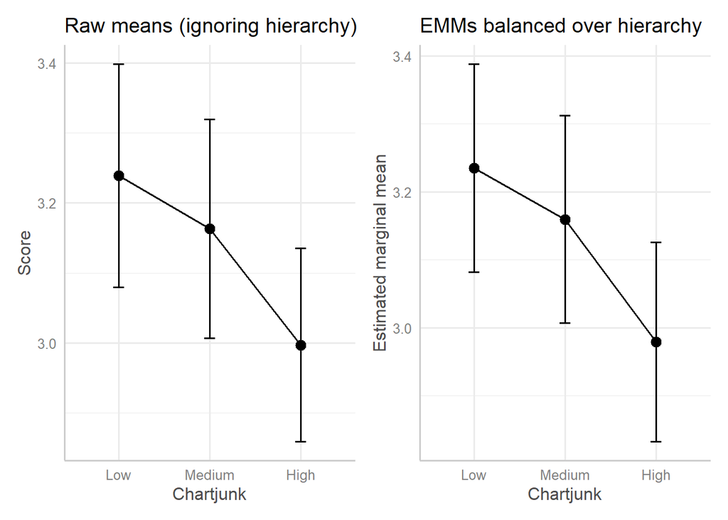

```r
emm_df <- as.data.frame(confint(emm_cj_eq))

p_adj <- ggplot(emm_df, aes(x = chartjunk, y = emmean, group = 1)) +
  geom_line() +
  geom_point(size = 3) +
  geom_errorbar(aes(ymin = lower.CL, ymax = upper.CL), width = .12) +
  labs(x = "Chartjunk", y = "Estimated marginal mean",
       title = "EMMs balanced over hierarchy") +
  theme_sjplot()

# Show side by side
p_raw | p_adj
```

```r
# ------------------------------------------------------------------------------

# If you want the adjusted version to use sample-mix instead of equal weighting:
# emm_cj_prop <- emmeans(m_aov, ~ chartjunk, weights = "proportional")
# as.data.frame(confint(emm_cj_prop))
```